# Jurimetria — A R de Araújo Comunicações ME

[figure not shown]

[figure not shown]

[figure not shown]

[figure not shown]

[figure not shown]

[figure not shown]

[figure not shown]

# Visão Geral

### Sentenças canônicas

243

### Taxa pró-consumidor (mérito)

88.3%

### Mediana de dano moral

R$ 5.000

### Sentenças por ano

[interactive chart not shown]

### Top 10 comarcas

[interactive chart not shown]

# Decisões

### Pró × Contra consumidor (mérito)

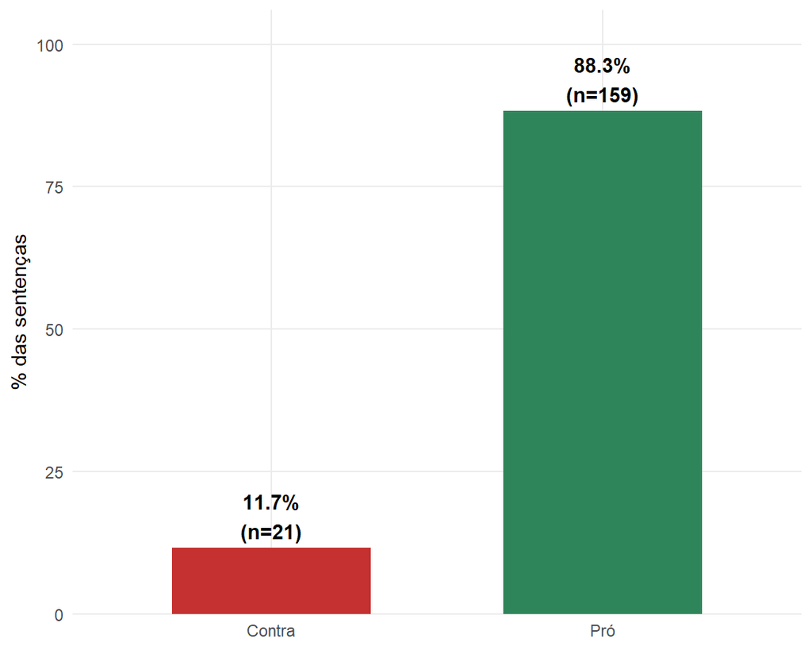

### Resultado por papel da empresa

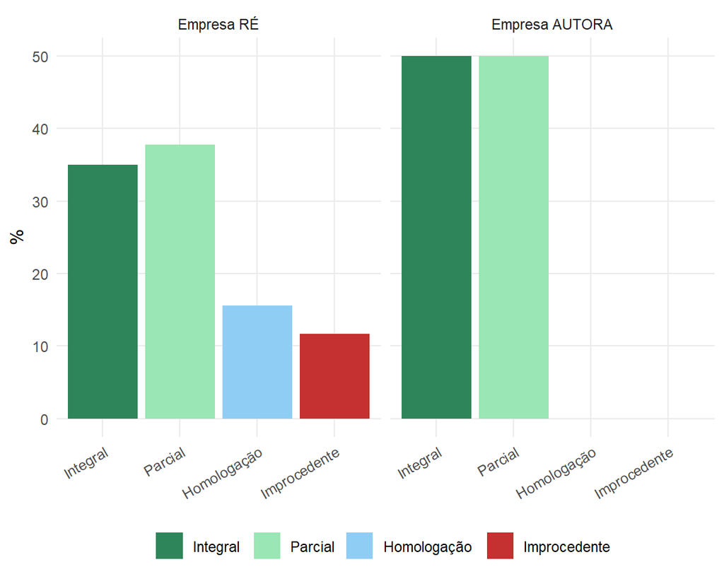

### Tipo de decisão (CPC)

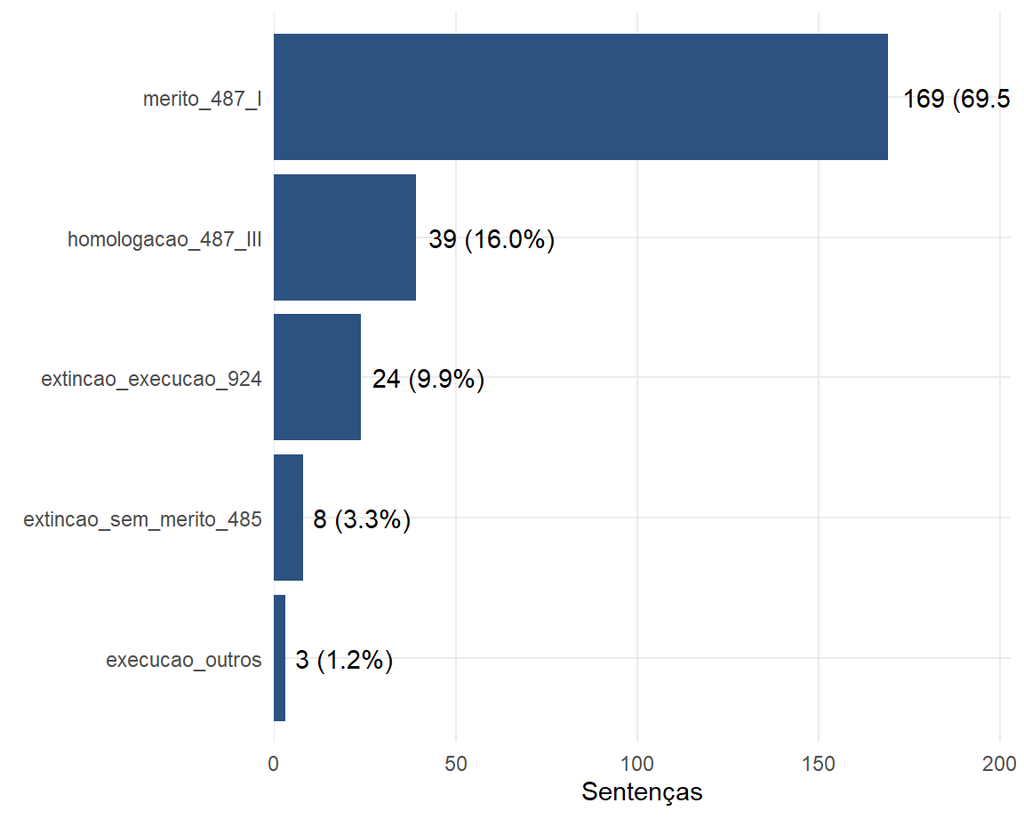

# Tempo de Tramitação

### Distribuição do tempo até sentença

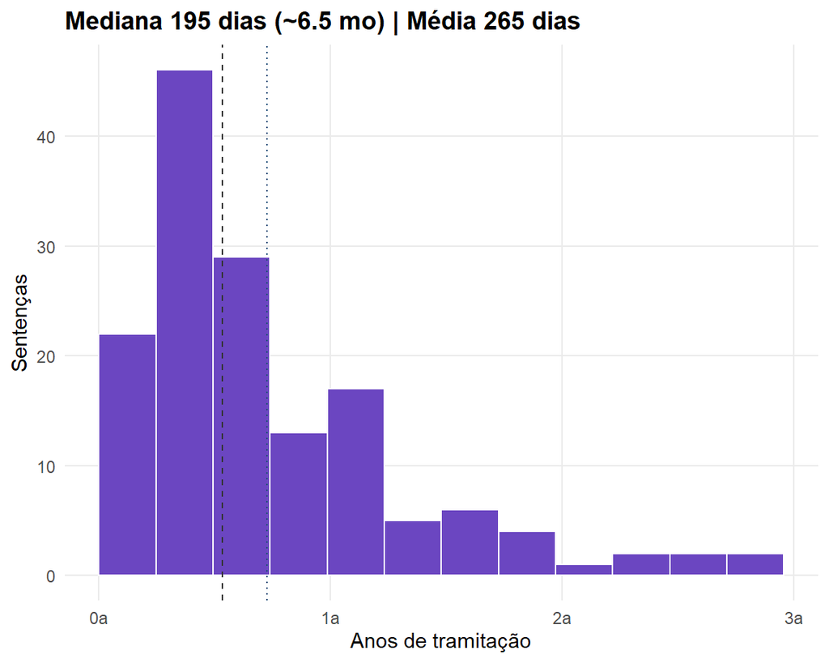

### Faixas de tempo

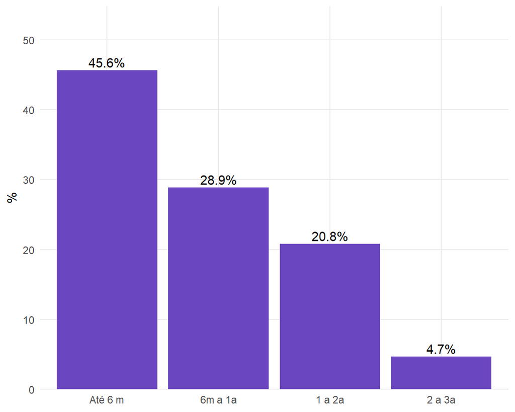

# Quantum

### Distribuição dos valores

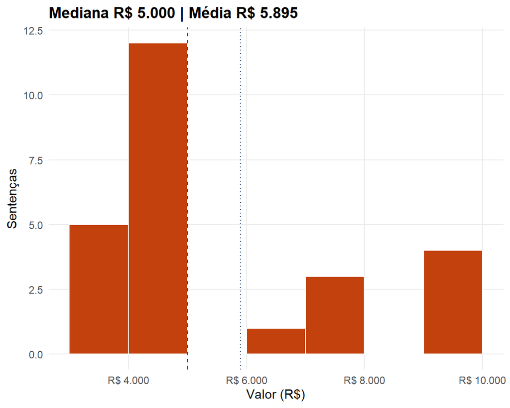

### Evolução do quantum por ano

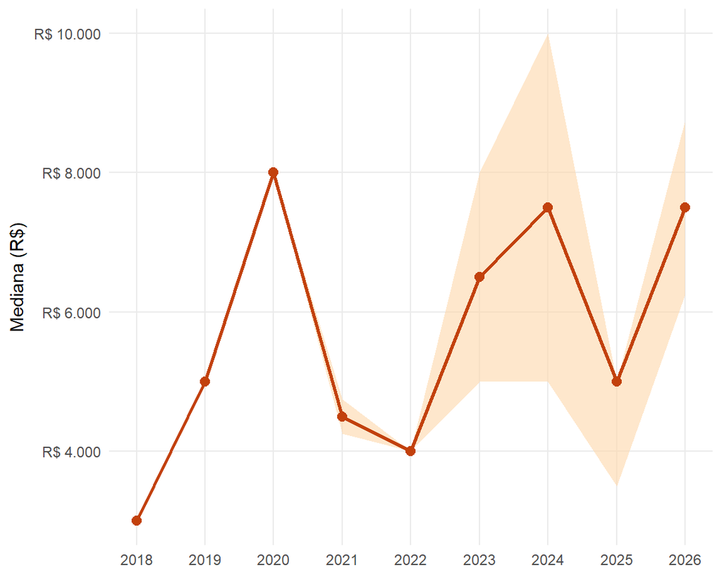

# Precedentes

### Top 30 precedentes (ranqueados por score 0-6)

[output not shown]

[output cut: 20 more lines]

# Todas as Sentenças

### 243 sentenças canônicas (filtros no topo de cada coluna)

| processo | data | comarca | classe | papel | tipo_decisao_cpc | resultado_dispositivo | favorabilidade | valor_morais | tempo_tramitacao_dias | tem_protesto | tem_danos | tem_duplicata | tem_contrato | dispositivo_txt |
| --- | --- | --- | --- | --- | --- | --- | --- | --- | --- | --- | --- | --- | --- | --- |
| 10008138820258260404 | 26/05/2026 | Orlândia | Procedimento Comum Cível |  | homologacao_487_III | homologacao | indefinido | 5000 | 412 | True | True | True | False | JULGO PROCEDENTES os pedidos formulados pela autora M. F. Orlândia Motores Elétricos Ltda em face da ré A. R. de Araújo Comunicações ME, resolvendo o mérito na forma do art. 487, I, do Código de Proce… |
| 10069485920258260132 | 18/05/2026 | SÃO PAULO | Procedimento Comum Cível | re | merito_487_I | parcial | consumidor_venceu | 10000 | 262 | True | True | True | True | JULGO PROCEDENTES os pedidos, para confirmar a tutela de urgência de fls. 172/174 e DECLARAR NULO o negócio jurídico consubstanciado no "Contrato de Figuração nº 85088 G" (fls. 19), declarando-se a in… |
| 10470148020258260100 | 10/04/2026 | SÃO PAULO | Procedimento Comum Cível | re | merito_487_I | improcedente | empresa_venceu |  | 366 | False | True | False | False | JULGO IMPROCEDENTE a ação proposta. Condeno a parte autora ao pagamento das custas e despesas processuais e dos honorários advocatícios em favor do patrono da ré, que fixo em 10% sobre o valor da caus… |
| 00003364420248260428 | 13/02/2026 | Paulínia | Procedimento do Juizado Especial Cível | re | merito_487_I | procedente | consumidor_venceu |  | 750 | False | False | False | False | julgo PROCEDENTE o pedido para: a) Declarar a nulidade do contrato nº 117794G, firmado entre as partes; b) Determinar o cancelamento imediato de qualquer cobrança oriunda do referido contrato; c) Cond… |
| 10055940420258260292 | 30/01/2026 | Jacareí | Procedimento Comum Cível | re | merito_487_I | parcial | consumidor_venceu |  | 247 | True | True | False | False | Ante o exposto, confirma-se a tutela de urgência (fls.38/39) e julga-se PARCIALMETNE PROCEDENTE a ação proposta por Delta RJA Sociedade Ltda. contra A. R. de Araújo Comunicações ME, nos termos do arti… |
| 10341056120258260114 | 19/01/2026 | Campinas | Procedimento Comum Cível | re | merito_487_I | improcedente | empresa_venceu |  | 166 | True | True | False | False | JULGO IMPROCEDENTES os pedidos formulados na inicial. Após o transito em julgado, oficie-se aos tabelionatos de protesto comunicando a revogação da liminar e a autorização para o prosseguimento dos ap… |
| 10007422820258260100 | 01/12/2025 | SÃO PAULO | Procedimento Comum Cível | autora | merito_487_I | parcial | consumidor_venceu |  | 328 | False | True | False | False | JULGO PARCIALMENTE PROCEDENTE a ação, nos termos do art. 487, inciso I, do Código de Processo Civil, para reconhecer a prescrição das parcelas vencidas dos cinco anos anteriores a fevereiro de 2023, q… |
| 10046004620258260010 | 26/11/2025 | SÃO PAULO | Procedimento Comum Cível | re | merito_487_I | procedente | consumidor_venceu | 5000 | 139 | True | True | True | False | JULGO PROCEDENTES os pedidos, para: (i) DECLARAR rescindido o contrato celebrado entre as partes, sem a incidência de qualquer multa; (ii) confirmando a liminar concedida às fls. 99/103, DECLARAR inex… |
| 10342890520258260506 | 14/11/2025 | Ribeirão Preto | Procedimento Comum Cível | re | merito_487_I | procedente | consumidor_venceu |  | 121 | False | False | False | False | JULGO PROCEDENTE o pedido em face de A R DE ARAÚJO COMUNICAÇÕES ME, e o faço para: (a) declarar a nulidade do Contrato de Figuração nº 102406G, firmado em 01/11/2022, reconhecendo a inexistência de re… |
| 10487019220258260100 | 12/11/2025 | Descalvado | Procedimento Comum Cível |  | merito_487_I | parcial | indefinido | 5000 | 215 | True | True | False | False | julgo parcialmente procedente a ação para declarar inexistente o débito da autora referente ao contrato nº 118662 (fl. 25). Confirmo os efeitos da tutela antecipada concedida às fls. 56/58. Após o trâ… |

[output cut: 233 more lines]

# Sobre

### Metodologia

**Objeto:** Pesquisa jurimétrica sobre **A R de Araújo Comunicações ME** (também conhecida como **Guia Plus** / **Lista Regional Brasil**), empresa investigada pela prática de cobrança por publicidade em lista telefônica não contratada, com posterior protesto de duplicatas e inscrição em cadastros de inadimplentes.

**Fonte:** TJSP — ESAJ (consultas CJSG e CJPG, dados públicos).

**Coleta:** pacote R [`{tjsp}`](https://github.com/jjesusfilho/tjsp) (Jose de Jesus Filho).

**Recorte temporal:** 2017–2026 (2026 incompleto).

**Base bruta:** 270 linhas de sentenças. Filtragem `decisao_canonica` para 243 sentenças únicas (descarta duplicatas do scraping e atos repetidos por processo).

**Pipeline:** 14 scripts numerados em `jurimetria_ar_de_araujo/`, do download à geração deste dashboard.

### Definições

- **`decisao_canonica`**: marca apenas 1 linha por processo, privilegiando decisão de mérito (art. 487) sobre execução (art. 924) e, dentro da mesma categoria, a mais recente.
- **`tipo_decisao_cpc`**: classificação automática em `merito_487_I`, `homologacao_487_III`, `extincao_sem_merito_485`, `extincao_execucao_924`.
- **`valor_morais`**: extraído do dispositivo (não do relatório/petição inicial). Filtro 500 ≤ valor ≤ 100.000.
- **`tempo_tramitacao_dias`**: `data_sentenca − MIN(dt_mov)` por processo (proxy para ajuizamento).
- **Pró-consumidor**: empresa ré + (procedente, parcial ou homologação) | empresa autora + improcedente.